# A06_G28512359

JINGSI WU

10/6/2018

# Part A Data cleaning

## Omit some coloumns and NA data

```r
head(train)
```

```
##   Id Product_Info_1 Product_Info_2 Product_Info_3 Product_Info_4
## 1  2              1             D3             10     0.07692308
## 2  5              1             A1             26     0.07692308
## 3  6              1             E1             26     0.07692308
## 4  7              1             D4             10     0.48717949
## 5  8              1             D2             26     0.23076923
## 6 10              1             D2             26     0.23076923
##   Product_Info_5 Product_Info_6 Product_Info_7    Ins_Age        Ht
## 1              2              1              1 0.64179104 0.5818182
## 2              2              3              1 0.05970149 0.6000000
## 3              2              3              1 0.02985075 0.7454545
## 4              2              3              1 0.16417910 0.6727273
## 5              2              3              1 0.41791045 0.6545455
## 6              3              1              1 0.50746269 0.8363636
##          Wt       BMI Employment_Info_1 Employment_Info_2
```

[output cut: 251 more lines]

```r
str(train)
```

```
## 'data.frame':    59381 obs. of  128 variables:
##  $ Id                 : int  2 5 6 7 8 10 11 14 15 16 ...
##  $ Product_Info_1     : int  1 1 1 1 1 1 1 1 1 1 ...
##  $ Product_Info_2     : chr  "D3" "A1" "E1" "D4" ...
##  $ Product_Info_3     : int  10 26 26 10 26 26 10 26 26 21 ...
##  $ Product_Info_4     : num  0.0769 0.0769 0.0769 0.4872 0.2308 ...
##  $ Product_Info_5     : int  2 2 2 2 2 3 2 2 2 2 ...
##  $ Product_Info_6     : int  1 3 3 3 3 1 3 3 3 3 ...
##  $ Product_Info_7     : int  1 1 1 1 1 1 1 1 1 1 ...
##  $ Ins_Age            : num  0.6418 0.0597 0.0299 0.1642 0.4179 ...
##  $ Ht                 : num  0.582 0.6 0.745 0.673 0.655 ...
##  $ Wt                 : num  0.149 0.132 0.289 0.205 0.234 ...
##  $ BMI                : num  0.323 0.272 0.429 0.352 0.424 ...
##  $ Employment_Info_1  : num  0.028 0 0.03 0.042 0.027 0.325 0.11 0.12 0.165 0.025 ...
##  $ Employment_Info_2  : int  12 1 9 9 9 15 1 12 9 1 ...
```

[output cut: 86 more lines]

By looking at some information about our dataset, we can see that there are some NA values, also there must be some redundant variables, but since most of the nominal variables have been turn to dummy variables, we can only remove ID and Product_Info_2 first, then remove the columns with NA.

```r
train <- subset(train, select = -c(Id, Product_Info_2 ))
train_flag <- apply(is.na(train), 2, sum)
train <- train[, which(train_flag == 0)]
```

Now let’s fit the remaining variables in to a multiple linear regression model.

```r
train_model <- glm(formula = Response ~ .,  data = train)
summary(train_model)
```

```
##
## Call:
## glm(formula = Response ~ ., data = train)
##
## Deviance Residuals:
##     Min       1Q   Median       3Q      Max
## -7.6872  -0.9233   0.5334   1.3225   6.9460
##
## Coefficients:
##                       Estimate Std. Error t value Pr(>|t|)
## (Intercept)         -1.989e+00  1.265e+00  -1.572 0.115994
## Product_Info_1      -1.280e-01  5.183e-02  -2.470 0.013500 *
## Product_Info_3      -7.837e-03  2.614e-03  -2.998 0.002721 **
## Product_Info_4       8.992e-01  3.162e-02  28.441  < 2e-16 ***
## Product_Info_5      -2.119e-01  9.910e-02  -2.138 0.032535 *
## Product_Info_6      -4.207e-02  1.130e-02  -3.721 0.000198 ***
## Product_Info_7       6.903e-02  2.822e-02   2.446 0.014447 *
## Ins_Age             -7.156e-01  5.526e-02 -12.949  < 2e-16 ***
## Ht                   2.978e+00  5.680e-01   5.243 1.58e-07 ***
## Wt                  -5.043e+00  8.723e-01  -5.781 7.46e-09 ***
## BMI                 -2.501e+00  5.078e-01  -4.925 8.46e-07 ***
## Employment_Info_2   -3.244e-03  2.993e-03  -1.084 0.278358
## Employment_Info_3   -1.805e-01  1.851e-02  -9.754  < 2e-16 ***
## Employment_Info_5    7.047e-02  3.759e-02   1.874 0.060876 .
## InsuredInfo_1       -1.580e-01  2.195e-02  -7.197 6.24e-13 ***
## InsuredInfo_2       -9.245e-01  1.118e-01  -8.271  < 2e-16 ***
## InsuredInfo_3       -3.458e-03  3.075e-03  -1.125 0.260793
## InsuredInfo_4        5.675e-03  2.608e-02   0.218 0.827719
## InsuredInfo_5       -6.581e-01  3.666e-02 -17.954  < 2e-16 ***
## InsuredInfo_6        2.548e-01  2.680e-02   9.509  < 2e-16 ***
## InsuredInfo_7       -4.064e-01  3.514e-02 -11.568  < 2e-16 ***
## Insurance_History_1 -3.468e-01  8.070e-02  -4.297 1.73e-05 ***
## Insurance_History_2 -4.109e-01  2.522e-02 -16.293  < 2e-16 ***
## Insurance_History_3  1.391e-01  6.320e-02   2.200 0.027793 *
## Insurance_History_4  5.766e-02  2.895e-02   1.992 0.046373 *
## Insurance_History_7  8.143e-02  4.285e-02   1.900 0.057386 .
## Insurance_History_8  1.087e-01  4.070e-02   2.671 0.007560 **
## Insurance_History_9 -7.095e-02  8.865e-02  -0.800 0.423481
## Family_Hist_1        2.989e-02  1.738e-02   1.720 0.085474 .
## Medical_History_2    1.733e-04  4.624e-05   3.747 0.000179 ***
```

[output cut: 78 more lines]

```
## Medical_Keyword_44  -4.773e-02  9.635e-02  -0.495 0.620308
## Medical_Keyword_45   3.947e-01  7.436e-02   5.308 1.11e-07 ***
## Medical_Keyword_46   2.105e-01  9.177e-02   2.294 0.021804 *
## Medical_Keyword_47  -1.104e-01  6.075e-02  -1.817 0.069286 .
## Medical_Keyword_48   9.916e-03  3.090e-01   0.032 0.974397
## ---
## Signif. codes:  0 '***' 0.001 '**' 0.01 '*' 0.05 '.' 0.1 ' ' 1
##
## (Dispersion parameter for gaussian family taken to be 3.972728)
##
##     Null deviance: 358419  on 59380  degrees of freedom
## Residual deviance: 235456  on 59268  degrees of freedom
## AIC: 250544
##
## Number of Fisher Scoring iterations: 2
```

```r
train <- subset(train, select = -c(Product_Info_1, Product_Info_5, Product_Info_7, Employment_Info_2, Employment_Info_5, InsuredInfo_3, InsuredInfo_4, Insurance_History_3, Insurance_History_4, Insurance_History_7, Insurance_History_9, Family_Hist_1, Medical_History_6, Medical_History_8, Medical_History_9, Medical_History_16, Medical_History_20, Medical_History_21, Medical_History_25, Medical_History_26, Medical_History_33, Medical_History_34, Medical_History_36, Medical_Keyword_1, Medical_Keyword_4, Medical_Keyword_5, Medical_Keyword_7, Medical_Keyword_8, Medical_Keyword_10, Medical_Keyword_11, Medical_Keyword_13, Medical_Keyword_14, Medical_Keyword_16, Medical_Keyword_17, Medical_Keyword_18, Medical_Keyword_20, Medical_Keyword_21, Medical_Keyword_23, Medical_Keyword_24, Medical_Keyword_27, Medical_Keyword_28, Medical_Keyword_29, Medical_Keyword_30, Medical_Keyword_32, Medical_Keyword_35, Medical_Keyword_36, Medical_Keyword_40, Medical_Keyword_42, Medical_Keyword_43, Medical_Keyword_44, Medical_Keyword_46, Medical_Keyword_47, Medical_Keyword_48, Medical_History_37, Medical_Keyword_12, Medical_Keyword_26))
```

## Use stepwise and VIF to remove variables

Then we’ll use stepwise method and checking VIF to remove other redundant variables.

```r
train_model <- glm(formula = Response ~ .,  data = train)
summary(train_model)
```

```
##
## Call:
## glm(formula = Response ~ ., data = train)
##
## Deviance Residuals:
##     Min       1Q   Median       3Q      Max
## -7.6378  -0.9284   0.5422   1.3313   7.2117
##
## Coefficients:
##                       Estimate Std. Error t value Pr(>|t|)
## (Intercept)          2.347e+00  7.206e-01   3.256 0.001129 **
## Product_Info_3      -1.121e-02  1.808e-03  -6.199 5.71e-10 ***
## Product_Info_4       8.987e-01  3.149e-02  28.537  < 2e-16 ***
## Product_Info_6      -3.723e-02  1.127e-02  -3.303 0.000958 ***
## Ins_Age             -7.142e-01  5.305e-02 -13.462  < 2e-16 ***
## Ht                   3.047e+00  5.679e-01   5.365 8.10e-08 ***
## Wt                  -5.211e+00  8.710e-01  -5.983 2.20e-09 ***
## BMI                 -2.463e+00  5.077e-01  -4.852 1.23e-06 ***
## Employment_Info_3   -1.619e-01  1.254e-02 -12.908  < 2e-16 ***
## InsuredInfo_1       -1.460e-01  2.167e-02  -6.735 1.66e-11 ***
## InsuredInfo_2       -9.170e-01  1.121e-01  -8.179 2.91e-16 ***
## InsuredInfo_5       -6.715e-01  3.671e-02 -18.291  < 2e-16 ***
## InsuredInfo_6        2.678e-01  2.646e-02  10.123  < 2e-16 ***
## InsuredInfo_7       -4.159e-01  3.516e-02 -11.827  < 2e-16 ***
## Insurance_History_1 -5.094e-01  3.221e-02 -15.819  < 2e-16 ***
## Insurance_History_2 -4.194e-01  2.526e-02 -16.601  < 2e-16 ***
## Insurance_History_8  1.846e-01  1.821e-02  10.137  < 2e-16 ***
## Medical_History_2    1.773e-04  4.635e-05   3.825 0.000131 ***
## Medical_History_3    3.083e-01  2.819e-02  10.936  < 2e-16 ***
## Medical_History_4    7.324e-01  1.832e-02  39.980  < 2e-16 ***
## Medical_History_5   -1.812e+00  9.591e-02 -18.891  < 2e-16 ***
## Medical_History_7    5.236e-01  6.068e-02   8.629  < 2e-16 ***
## Medical_History_11   6.072e-01  8.818e-02   6.886 5.80e-12 ***
## Medical_History_12  -1.670e-01  3.952e-02  -4.226 2.38e-05 ***
## Medical_History_13   2.916e-01  1.331e-02  21.907  < 2e-16 ***
## Medical_History_14   3.048e-01  5.359e-02   5.688 1.29e-08 ***
## Medical_History_17   6.172e-01  7.102e-02   8.690  < 2e-16 ***
## Medical_History_18  -7.184e-01  4.632e-02 -15.511  < 2e-16 ***
## Medical_History_19  -3.291e-01  4.573e-02  -7.197 6.21e-13 ***
## Medical_History_22   3.887e-01  6.713e-02   5.791 7.05e-09 ***
```

[output cut: 22 more lines]

```
## Medical_Keyword_37  -1.640e-01  3.428e-02  -4.785 1.71e-06 ***
## Medical_Keyword_38  -9.868e-01  1.093e-01  -9.029  < 2e-16 ***
## Medical_Keyword_39   2.255e-01  7.753e-02   2.908 0.003638 **
## Medical_Keyword_41   9.477e-01  9.256e-02  10.239  < 2e-16 ***
## Medical_Keyword_45   3.608e-01  7.418e-02   4.864 1.15e-06 ***
## ---
## Signif. codes:  0 '***' 0.001 '**' 0.01 '*' 0.05 '.' 0.1 ' ' 1
##
## (Dispersion parameter for gaussian family taken to be 4.00482)
##
##     Null deviance: 358419  on 59380  degrees of freedom
## Residual deviance: 237582  on 59324  degrees of freedom
## AIC: 250966
##
## Number of Fisher Scoring iterations: 2
```

```r
library(MASS)
stepwise <- stepAIC(train_model, direction = "both")
```

```
## Start:  AIC=250966
## Response ~ Product_Info_3 + Product_Info_4 + Product_Info_6 +
##     Ins_Age + Ht + Wt + BMI + Employment_Info_3 + InsuredInfo_1 +
##     InsuredInfo_2 + InsuredInfo_5 + InsuredInfo_6 + InsuredInfo_7 +
##     Insurance_History_1 + Insurance_History_2 + Insurance_History_8 +
##     Medical_History_2 + Medical_History_3 + Medical_History_4 +
##     Medical_History_5 + Medical_History_7 + Medical_History_11 +
##     Medical_History_12 + Medical_History_13 + Medical_History_14 +
##     Medical_History_17 + Medical_History_18 + Medical_History_19 +
##     Medical_History_22 + Medical_History_23 + Medical_History_27 +
##     Medical_History_28 + Medical_History_29 + Medical_History_30 +
##     Medical_History_31 + Medical_History_35 + Medical_History_38 +
##     Medical_History_39 + Medical_History_40 + Medical_History_41 +
##     Medical_Keyword_2 + Medical_Keyword_3 + Medical_Keyword_6 +
##     Medical_Keyword_9 + Medical_Keyword_15 + Medical_Keyword_19 +
##     Medical_Keyword_22 + Medical_Keyword_25 + Medical_Keyword_31 +
##     Medical_Keyword_33 + Medical_Keyword_34 + Medical_Keyword_37 +
##     Medical_Keyword_38 + Medical_Keyword_39 + Medical_Keyword_41 +
##     Medical_Keyword_45
##
##                       Df Deviance    AIC
## <none>                     237582 250966
## - Medical_Keyword_39   1   237616 250972
## - Product_Info_6       1   237626 250975
## - Medical_Keyword_31   1   237634 250977
## - Medical_History_41   1   237635 250977
## - Medical_Keyword_15   1   237638 250978
## - Medical_History_2    1   237641 250979
## - Medical_Keyword_2    1   237644 250980
## - Medical_Keyword_19   1   237648 250980
## - Medical_Keyword_6    1   237650 250981
## - Medical_History_12   1   237653 250982
## - Medical_History_38   1   237661 250984
## - Medical_Keyword_37   1   237674 250987
## - BMI                  1   237676 250988
## - Medical_History_29   1   237677 250988
## - Medical_Keyword_45   1   237677 250988
## - Medical_Keyword_34   1   237691 250991
## - Ht                   1   237697 250993
## - Medical_History_14   1   237712 250996
```

[output cut: 23 more lines]

```
## - Medical_History_27   1   238151 251106
## - Employment_Info_3    1   238249 251131
## - Ins_Age              1   238308 251145
## - Medical_History_18   1   238545 251204
## - Insurance_History_1  1   238584 251214
## - Insurance_History_2  1   238686 251239
## - Medical_History_40   1   238905 251294
## - InsuredInfo_5        1   238922 251298
## - Medical_History_30   1   238985 251314
## - Medical_History_5    1   239011 251320
## - Medical_History_23   1   239135 251351
## - Medical_History_13   1   239504 251442
## - Medical_Keyword_3    1   240103 251591
## - Product_Info_4       1   240843 251774
## - Medical_History_4    1   243983 252543
```

```r
train <- subset(train, select = c(Response, Product_Info_3, Product_Info_4, Product_Info_6,
    Ins_Age, Ht, Wt, BMI, Employment_Info_3, InsuredInfo_1,
    InsuredInfo_2, InsuredInfo_5, InsuredInfo_6, InsuredInfo_7,
    Insurance_History_1, Insurance_History_2, Insurance_History_8,
    Medical_History_2, Medical_History_3, Medical_History_4,
    Medical_History_5, Medical_History_7, Medical_History_11,
    Medical_History_12, Medical_History_13, Medical_History_14,
    Medical_History_17, Medical_History_18, Medical_History_19,
    Medical_History_22, Medical_History_23, Medical_History_27,
    Medical_History_28, Medical_History_29, Medical_History_30,
    Medical_History_31, Medical_History_35, Medical_History_38,
    Medical_History_39, Medical_History_40, Medical_History_41,
    Medical_Keyword_2, Medical_Keyword_3, Medical_Keyword_6,
    Medical_Keyword_9, Medical_Keyword_15, Medical_Keyword_19,
    Medical_Keyword_22, Medical_Keyword_25, Medical_Keyword_31,
    Medical_Keyword_33, Medical_Keyword_34, Medical_Keyword_37,
    Medical_Keyword_38, Medical_Keyword_39, Medical_Keyword_41,
    Medical_Keyword_45))
```

```r
train_model <- glm(formula = Response~.,  data = train)
vif(train_model)
```

```
##      Product_Info_3      Product_Info_4      Product_Info_6
##            1.247355            1.174121            1.029283
##             Ins_Age                  Ht                  Wt
##            1.622632           26.351291           89.171800
##                 BMI   Employment_Info_3       InsuredInfo_1
##           57.091401            1.192890            1.216490
##       InsuredInfo_2       InsuredInfo_5       InsuredInfo_6
##            1.373686            1.071644            2.509094
##       InsuredInfo_7 Insurance_History_1 Insurance_History_2
##            1.385386            3.047988            1.026220
## Insurance_History_8   Medical_History_2   Medical_History_3
##            2.804500            1.016292            1.082783
##   Medical_History_4   Medical_History_5   Medical_History_7
##            1.124777            1.005517            1.622130
##  Medical_History_11  Medical_History_12  Medical_History_13
##            1.047905            1.237252            1.077279
##  Medical_History_14  Medical_History_17  Medical_History_18
##            1.664590            1.611310            1.622503
##  Medical_History_19  Medical_History_22  Medical_History_23
##            1.036876            1.203933            4.416450
##  Medical_History_27  Medical_History_28  Medical_History_29
##            1.025152            1.040995            1.338610
##  Medical_History_30  Medical_History_31  Medical_History_35
##            1.498715            1.004103            1.002914
##  Medical_History_38  Medical_History_39  Medical_History_40
##            1.056737            2.662857            1.120569
##  Medical_History_41   Medical_Keyword_2   Medical_Keyword_3
##            1.135632            1.199504            2.481875
##   Medical_Keyword_6   Medical_Keyword_9  Medical_Keyword_15
##            1.114018            1.006100            4.070636
##  Medical_Keyword_19  Medical_Keyword_22  Medical_Keyword_25
##            1.594625            1.059909            1.333360
##  Medical_Keyword_31  Medical_Keyword_33  Medical_Keyword_34
##            1.015265            1.098601            1.588721
##  Medical_Keyword_37  Medical_Keyword_38  Medical_Keyword_39
##            1.083072            1.202688            1.200588
##  Medical_Keyword_41  Medical_Keyword_45
##            1.264352            1.101685
```

By omiting all the variables above we can get the final dataset for our model.

```r
train <- subset(train, select = -c(Ht, Wt, BMI))
```

# Part B Visualizations

For the remaining variables, we want to know more about the relationship between dependent variables and continuous independent variables, so we choose Product_Info_4 and Ins_Age for visualization.

```r
train_reg <- lm(Response~Product_Info_4+Ins_Age, data = train)
summary(train_reg)
```

```
##
## Call:
## lm(formula = Response ~ Product_Info_4 + Ins_Age, data = train)
##
## Residuals:
##     Min      1Q  Median      3Q     Max
## -6.3175 -1.5846  0.7676  1.8895  3.6746
##
## Coefficients:
##                Estimate Std. Error t value Pr(>|t|)
## (Intercept)     6.03344    0.02812  214.59   <2e-16 ***
## Product_Info_4  1.37793    0.03570   38.60   <2e-16 ***
## Ins_Age        -2.09553    0.05116  -40.96   <2e-16 ***
## ---
## Signif. codes:  0 '***' 0.001 '**' 0.01 '*' 0.05 '.' 0.1 ' ' 1
##
## Residual standard error: 2.373 on 59378 degrees of freedom
## Multiple R-squared:  0.06734,    Adjusted R-squared:  0.0673
## F-statistic:  2143 on 2 and 59378 DF,  p-value: < 2.2e-16
```

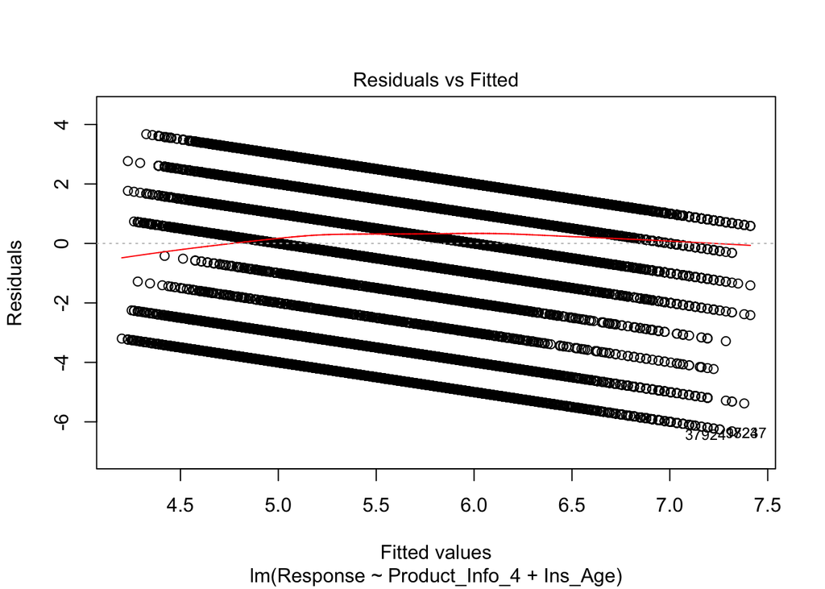

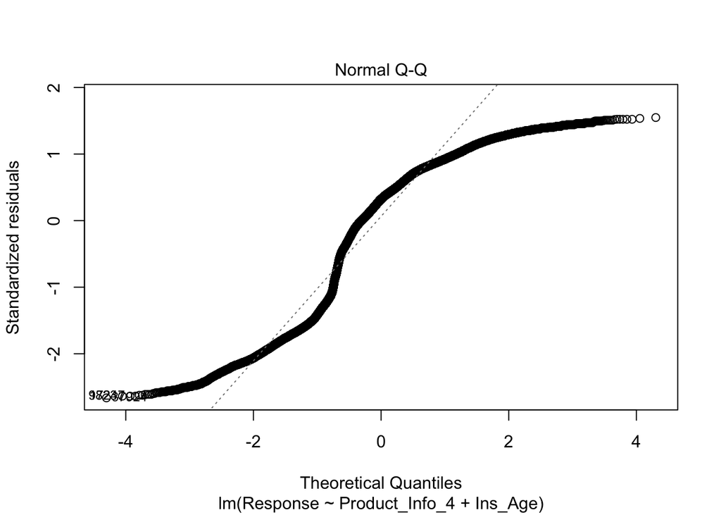

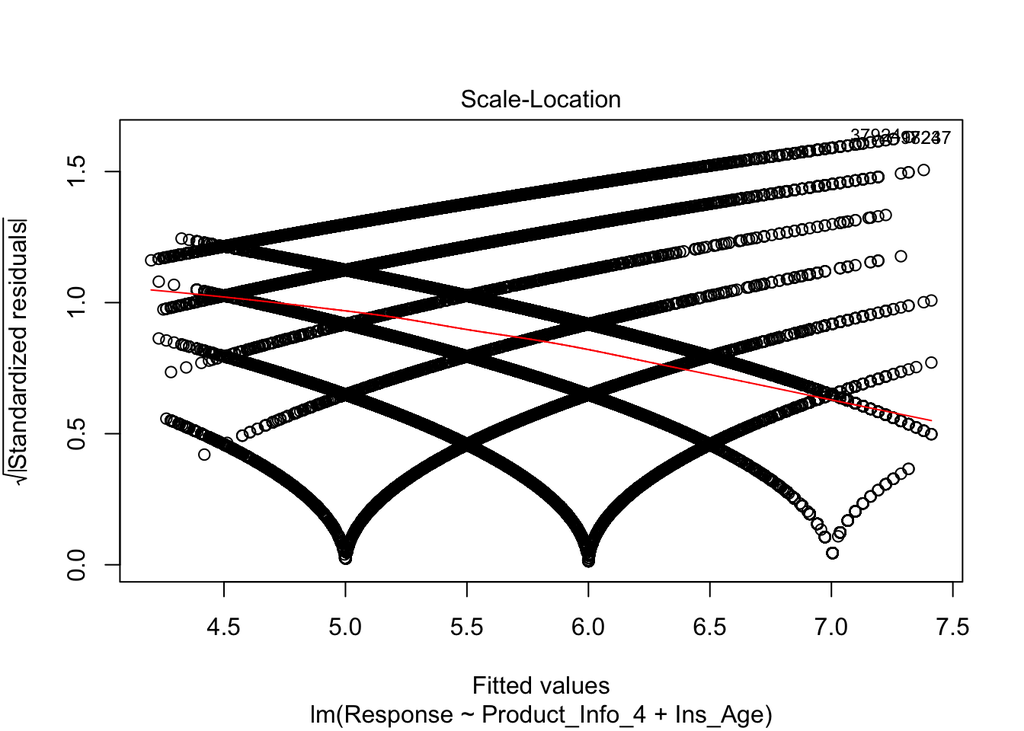

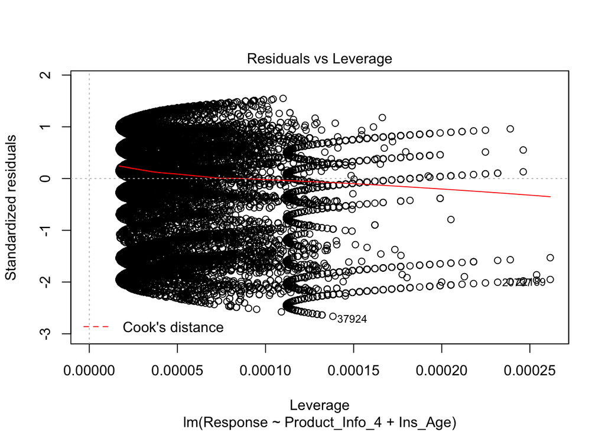

```r
plot(train_reg)
```

From the picture and the summary we can conclude that both two variables can significantly explain the value of Response, but not as a linear regression model, so now we are going to fit the whole dataset with other machine learning model.

# Part C Fit dataset with decision tree model

```r
library(rpart)
train_tree <- rpart(formula= Response~., data=train, method = "class")
test <- read.csv('test.csv',stringsAsFactors = FALSE, na.strings = "")
prediction <- predict(train_tree, test,type = 'class')
predictresult<-as.matrix(prediction)
colnames(predictresult)<-'Response'
output<-cbind(test$Id, predictresult)
write.csv(output,'prediction.csv',row.names = FALSE)
```